# Tarea 10 - Modelos Lineales

Shanthal Chavarría

2021-12-21

```
## [1] "es_ES.UTF-8/es_ES.UTF-8/es_ES.UTF-8/C/es_ES.UTF-8/en_US.UTF-8"
```

# 1. **[30 puntos]** Para este ejercicio usaremos la serie tiempo `hsales` sobre ventas mensuales de casas

del paquete `fpp2` (también están en el archivo `ventas_casas.csv`). Utilizando todos los datos realice lo siguiente:

## a) Cargue los datos como sigue: `serie.hsales <- hsales`.

```r
library(fpp2)

serie.hsales <- hsales
```

## b) Grafique la serie de tiempo `serie.hsales`.

```r
library(xts)
library(dplyr)
library(ggplot2)
library(forecast)
library(dygraphs)
library(lubridate)

dygraph(serie.hsales, width = "100%") %>%
    dyRangeSelector()
```

[interactive chart not shown]

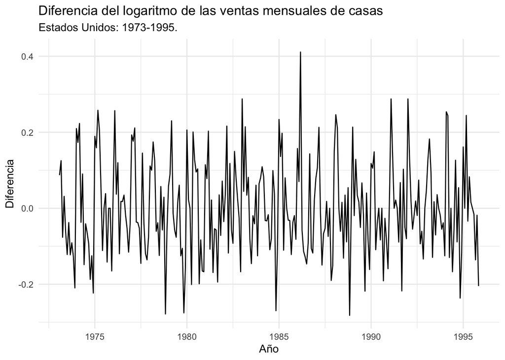

```r
log.dif.hsales <- diff(log(serie.hsales))
autoplot(log.dif.hsales, main = "Diferencia del logaritmo de las ventas mensuales de casas") +
    labs(subtitle = "Estados Unidos: 1973-1995.") + xlab("Año") + ylab("Diferencia") +
    theme_minimal()
```

## d) Usando la serie original `serie.hsales`, encuentre el tercer periodo más importante, luego grafique el periodograma.

```r
# Calculamos el espectro y la frecuencia con la función spec.pgram.
res <- spec.pgram(serie.hsales, log = "no", plot = F)

# Ordenamos el espectro con respecto a la frecuencia en orden decreciente
max <- order(res$spec, res$freq, decreasing = TRUE)

# Tomamos las primeras 3 posiciones. El valor 1 no se toma en cuenta pues es
# toda la serie.
max <- max[max != 1][1:3]

# Tomamos de las frecuencias las posiciones obtenidas.

max <- res$freq[max]

# Finalmente obtenemos los periodos más importantes, se usa 12 en el numerador
# porque la frecuencia es 12.

periodos <- 12/max
periodos
```

```
[1]  96  12 144
```

```r
dygraph(res, "Peridiograma", "Frecuencia", "Espectro", width = "100%") %>%
    dyEvent(max[1], color = "green") %>%
    dyEvent(max[2], color = "red") %>%
    dyEvent(max[3], color = "navy") %>%
    dyRangeSelector() %>%
    dyOptions(drawPoints = TRUE, pointSize = 2)
```

[interactive chart not shown]

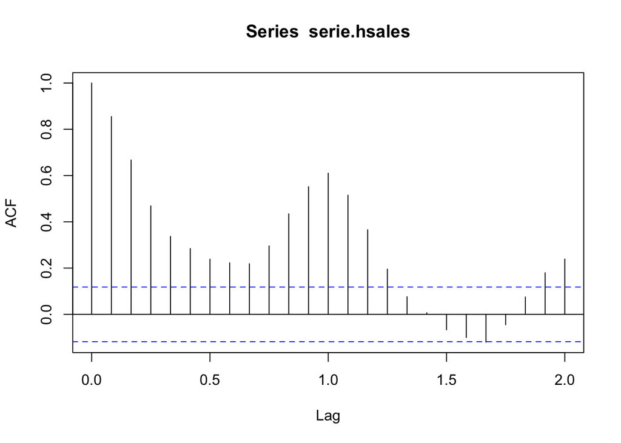

```r
acf(serie.hsales)
```

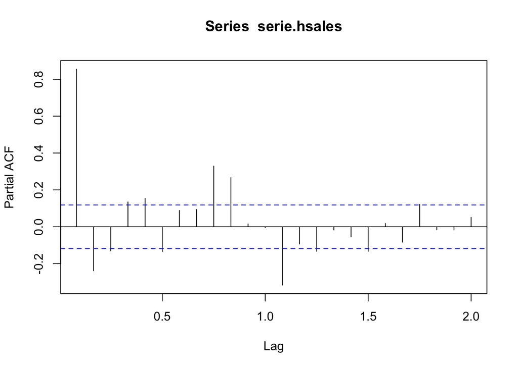

```r
pacf(serie.hsales)
```

```r
train <- head(serie.hsales, -12)
test <- tail(serie.hsales, 12)

modelo <- arima(serie.hsales, order = c(0, 1, 1), seasonal = list(order = c(2, 1,
    2), period = 12))
pred <- predict(modelo, n.ahead = 12)
pred
```

```
$pred
          Jan      Feb      Mar      Apr      May      Jun      Jul      Aug
1995
1996 46.03659 51.27221 61.88981 60.44726 60.50672 58.17039 55.31026 56.46140
          Sep      Oct      Nov      Dec
1995                            40.58330
1996 51.69726 50.64374 43.54295

$se
           Jan       Feb       Mar       Apr       May       Jun       Jul
1995
1996  6.099350  7.331701  8.384843  9.319729 10.169027 10.952665 11.683862
           Aug       Sep       Oct       Nov       Dec
1995                                          4.540939
1996 12.371919 13.023676 13.644335 14.237965
```

## g) Genere también los métodos HOLT-WINTERS, HOLT-WINTERS Calibrado, Redes Neuronales, AUTO ARIMA y ARIMA CALIBRADO y compare los resultados.

### Holt-Winters

```r
modelo.HW <- hw(train, h = 12)
pred.HW <- forecast(modelo.HW, h = 12)
```

### Calibrado Holt-Winters

```r
calibrar.HW <- function(entrenamiento, prueba, paso = 0.1) {
    # se calculan todas las combinaciones para los parametros
    params <- purrr::cross(list(a = seq(0, 1, by = paso), b = seq(0, 1, by = paso),
        g = seq(0, 1, by = paso)))

    # se calcula un modelos para cada combinacion de parametros
    hw_secure <- purrr::possibly(forecast::hw, otherwise = NULL)
    models <- invisible(purrr::map(params, ~suppressWarnings(hw_secure(entrenamiento,
        alpha = ifelse(.$a == 0, F, .$a), beta = ifelse(.$b == 0, F, .$b), gamma = ifelse(.$g ==
            0, F, .$g), h = length(prueba)))))

    # se realiza la prediccion con cada uno de los modelos
    predictions <- purrr::map(models, ~{
        if (is.null(.)) {
            return(NULL)
        }
        forecast(., h = length(prueba))
    })

    # se calcula el error para cada prediccion
    error <- purrr::map_dbl(predictions, ~{
        if (is.null(.)) {
            return(Inf)
        }
        sum((as.numeric(prueba) - as.numeric(.$mean))^2)
    })

    # se retorna el modelo con el menor error
    best_model <- models[[which.min(error)]]
    p <- params[[which.min(error)]]
    best_model$call <- call("HoltWinters", y = quote(datos), alpha = ifelse(p$a ==
        0, F, p$a), beta = ifelse(p$b == 0, F, p$b), gamma = ifelse(p$g == 0, F,
        p$g))
    return(best_model$call)
}

calibrar.HW(train, test)
```

[output not shown]

[output cut: 472 more lines]

```
HoltWinters(y = datos, alpha = 0.4, beta = 0.1, gamma = 0.3)
```

```r
modelo.calibrado <- hw(train, alpha = 0.4, beta = 0.1, gamma = 0.3, h = 12)
pred.calibrado <- forecast(modelo.calibrado, h = 12)
```

### Redes Neuronales

```r
modelo.RN <- nnetar(train, size = 40)
pred.RN <- forecast(modelo.RN, h = 12)
```

### Auto-Arima

```r
auto.arima(train)
```

```
Series: train
ARIMA(1,0,0)(1,1,0)[12]

Coefficients:
         ar1     sar1
      0.8897  -0.4183
s.e.  0.0296   0.0590

sigma^2 estimated as 27.72:  log likelihood=-773.91
AIC=1553.82   AICc=1553.91   BIC=1564.39
```

```r
modelo.arima <- arima(train, order = c(1, 0, 0), seasonal = list(order = c(1, 1,
    0), period = 12))
pred.arima <- predict(modelo.arima, n.ahead = 12)
```

### ARIMA Calibrado

```r
calibrar.arima <- function(entrenamiento = NULL, prueba = NULL, periodo = NA_integer_,
    ar = 0:2, es = 0:1) {
    # se calculan todas las combinaciones para los parametros
    params <- purrr::cross(list(a = ar, b = ar, c = ar, d = es, e = es, f = es))

    # se calcula un modelos para cada combinacion de parametros
    arima_secure <- purrr::possibly(stats::arima, otherwise = NULL)
    models <- purrr::map(params, ~suppressWarnings(arima_secure(entrenamiento, order = c(.$a,
        .$b, .$c), seasonal = list(order = c(.$d, .$e, .$f), period = periodo))))

    # se realiza la prediccion con cada uno de los modelos
    predictions <- purrr::map(models, ~{
        if (is.null(.)) {
            return(NULL)
        }
        forecast(., h = length(prueba))
    })

    # se calcula el error para cada prediccion
    error <- purrr::map_dbl(predictions, ~{
        if (is.null(.)) {
            return(Inf)
        }
        sum((as.numeric(prueba) - as.numeric(.$mean))^2)
    })

    # se retorna el modelo con el menor error
    best_model <- models[[which.min(error)]]
    p <- params[[which.min(error)]]
    best_model$call <- call("arima", x = quote(datos), order = as.numeric(c(p$a,
        p$b, p$c)), seasonal = list(order = as.numeric(c(p$d, p$e, p$f)), period = periodo))
    return(best_model)
}
```

```r
calibrar.arima(train, test, periodo = 12, 0:3, 0:1)
```

```
Call:
arima(x = datos, order = c(1, 2, 3), seasonal = list(order = c(0, 1, 1), period = 12))

Coefficients:
         ar1      ma1     ma2     ma3     sma1
      0.5406  -1.6482  0.5904  0.0579  -0.9948
s.e.  0.2084   0.2150  0.2798  0.0796   0.1006

sigma^2 estimated as 19.82:  log likelihood = -750.89,  aic = 1513.78
```

```r
modelo.arima.calibrado <- arima(train, order = c(1, 2, 3), seasonal = list(order = c(0,
    1, 1), period = 12))

pred.arima.calibrado <- predict(modelo.arima.calibrado, n.ahead = 12)
```

### Errores

```r
RSS <- function(Pred, Real) {
    return(sum((Real - Pred)^2))
}
MSE <- function(Pred, Real) {
    N <- length(Real)
    rss <- sum((Real - Pred)^2)
    return((1/N) * rss)
}
RMSE <- function(Pred, Real) {
    N <- length(Real)
    rss <- sum((Real - Pred)^2)
    return(sqrt((1/N) * rss))
}
RE <- function(Pred, Real) {
    res <- sum(abs(Real - Pred))/sum(abs(Real))
    return(res)
}

tabla.errores <- function(predicciones, real, nombres = NULL) {
    r <- data.frame()
    for (pred in predicciones) {
        r <- rbind(r, data.frame(MSE = MSE(pred, real), RMSE = RMSE(pred, real),
            RE = RE(pred, real), CORR = cor(pred, real)))
    }
    row.names(r) <- nombres
    return(r)
}

grafico.errores <- function(errores) {
    library(ggplot2)
    library(reshape)

    centros <- as.data.frame(apply(errores, 2, function(i) scales::rescale(i, to = c(0,
        100))))

    res <- melt(t(centros), varnames = c("E", "Modelos"))
    res <- res[order(res$E, decreasing = F), ]
    res$M <- as.character(res$M)
    y = c(0, 25, 50, 75, 100)

    ggplot(res, aes(x = E, y = value, group = Modelos, color = Modelos, fill = Modelos)) +
        geom_polygon(alpha = 0.3, size = 1) + geom_point(size = 3) + theme_minimal() +
        theme(axis.text.y = element_blank()) + xlab("") + ylab("") + scale_y_continuous(limits = c(-10,
        100), breaks = y) + annotate("text", x = 0.5, y = y, label = paste0(y, "%"),
        color = "gray60") + ggproto("CordRadar", CoordPolar, theta = "x", r = "y",
        start = 0, direction = sign(1))
}

errores <- tabla.errores(predicciones = list(pred.arima$pred, pred.arima.calibrado$pred,
    pred.HW$mean, pred.calibrado$mean, pred.RN$mean), real = test)

row.names(errores) <- c("AUTO.ARIMA", "ARIMA FUERZA BRUTA", "HOLT-WINTERS", "HW FUERZA BRUTA",
    "REDES")

errores
```

|  | MSE | RMSE | RE | CORR |
| --- | --- | --- | --- | --- |
| AUTO.ARIMA | 35.06551 | 5.921614 | 0.09349847 | 0.7091096 |
| ARIMA FUERZA BRUTA | 16.60543 | 4.074977 | 0.05966022 | 0.8691582 |
| HOLT-WINTERS | 18.88370 | 4.345538 | 0.06712758 | 0.8491618 |
| HW FUERZA BRUTA | 20.60809 | 4.539614 | 0.07214856 | 0.9131401 |
| REDES | 30.14004 | 5.489995 | 0.08545948 | 0.7589722 |

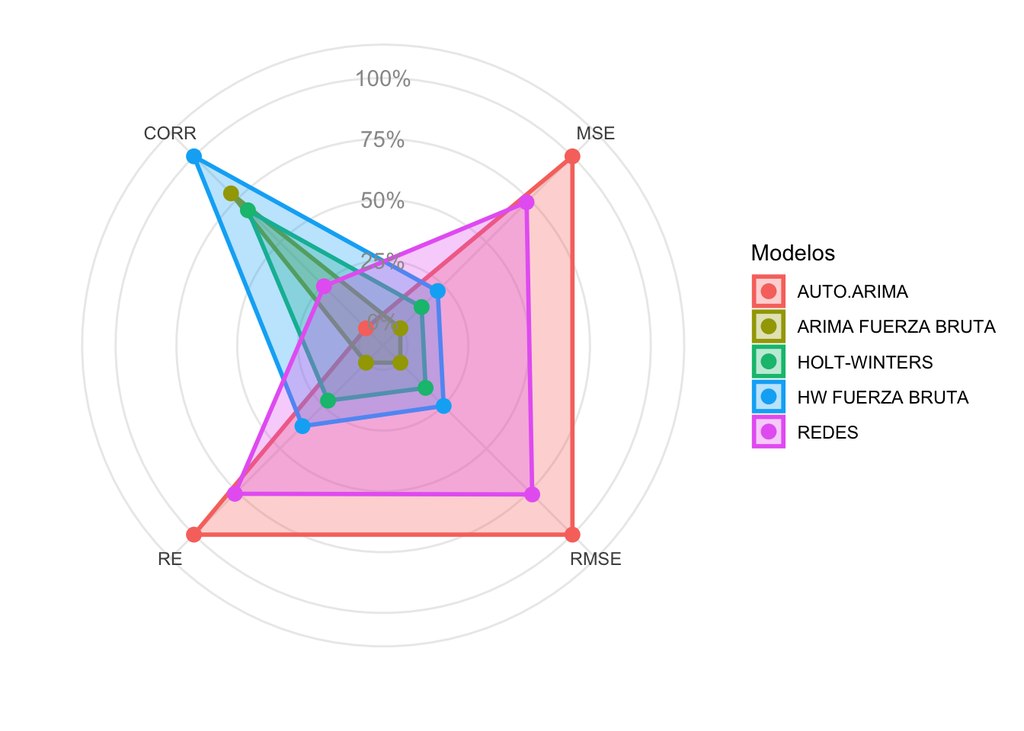

```r
grafico.errores(errores)
```

```r
predicciones <- ts.union(train, original = test, AUTO.ARIMA = pred.arima$pred, `arima Fuerza Bruta` = pred.arima.calibrado$pred,
    `Holt-Winters` = pred.HW$mean, `HW Fuerza Bruta` = pred.calibrado$mean, `Redes Neuronales` = pred.RN$mean)

dygraph(predicciones, width = "100%") %>%
    dyRangeSelector()
```

[interactive chart not shown]

# 2. [30 puntos] El archivo `covid19_CR.csv` contiene la cantidad de casos nuevos diarios de Covid 19 registrados en Costa Rica desde el 6 de marzo del 2020 hasta el 23 de abril de 2021, cargue la tabla de datos y realice lo siguiente:

```r
datos <- read.table("../datos/covid19_CR.csv", sep = ";", dec = ".", header = T)
```

## a) Convierta a serie de tiempo `ts` utilizando una frecuencia de forma que el Patrón-Estacional sea semanal.

```r
library(lubridate)
library(dplyr)

datos <- datos %>%
    mutate(FECHA = as.POSIXct(FECHA, format = "%Y-%m-%d"))

fecha.inicio <- datos[1, 1]
fecha.final <- datos[nrow(datos), 1]

serie <- ts(datos$casos_nuevos, frequency = 7, start = c(1, wday(fecha.inicio)))
```

## b) Gráfique la autocorrelación Simple y la Parcial.

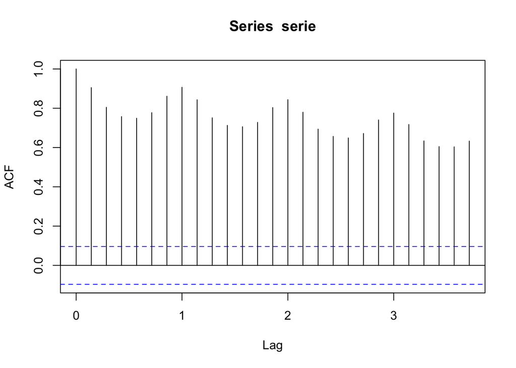

```r
acf(serie)
```

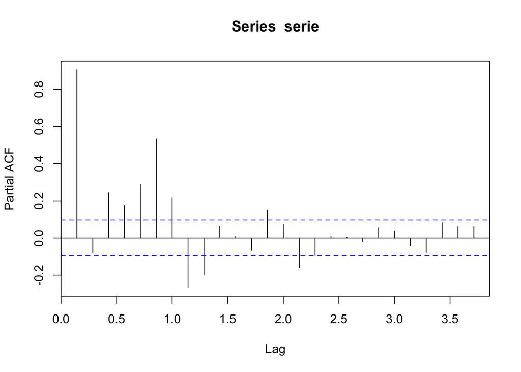

```r
pacf(serie)
```

3. Determine y grafique los 3 periodos más importantes

```r
# Calculamos el espectro y la frecuencia con la función spec.pgram.
res <- spec.pgram(serie, log = "no", plot = F)

# Ordenamos el espectro con respecto a la frecuencia en orden decreciente
max <- order(res$spec, res$freq, decreasing = TRUE)

# Tomamos las primeras 3 posiciones. El valor 1 no se toma en cuenta pues es
# toda la serie.
max <- max[max != 1][1:3]

# Tomamos de las frecuencias las posiciones obtenidas.

max <- res$freq[max]

# Finalmente obtenemos los periodos más importantes, se usa 12 en el numerador
# porque la frecuencia es 12.

periodos <- 7/max
periodos
```

```
[1] 216.000000 144.000000   6.967742
```

```r
dygraph(res, "Peridiograma", "Frecuencia", "Espectro", width = "100%") %>%
    dyEvent(max[1], color = "green") %>%
    dyEvent(max[2], color = "red") %>%
    dyEvent(max[3], color = "navy") %>%
    dyRangeSelector() %>%
    dyOptions(drawPoints = TRUE, pointSize = 2)
```

[interactive chart not shown]

## d) Usando el último mes de abril para pruebas y el resto de fechas para entrenamiento genere modelos utilizando `HOLT-WINTERS`, `HOLT-WINTERS Calibrado`, `Redes Neuronales`, `AUTO ARIMA` y `ARIMA CALIBRADO`, para este último utilice el tercer periodo más importante encontrado en el punto anterior, luego en un solo gráfico muestre la serie de entrenamiento, la serie de prueba y el resultado de la predicción de cada uno de los modelos anteriores.

```r
train <- head(serie, -23)
test <- tail(serie, 23)
```

### Holt-Winters

```r
modelo.HW <- hw(train, h = 23)
pred.HW <- forecast(modelo.HW, h = 23)
```

### Calibrado Holt-Winters

```r
calibrar.HW(train, test)
```

[output not shown]

[output cut: 413 more lines]

```
HoltWinters(y = datos, alpha = 0.4, beta = 0.3, gamma = 0.1)
```

```r
modelo.calibrado <- hw(train, alpha = 0.4, beta = 0.3, gamma = 0.1, h = 23)
pred.calibrado <- forecast(modelo.calibrado, h = 23)
```

### Redes Neuronales

```r
modelo.RN <- nnetar(train, size = 40)
pred.RN <- forecast(modelo.RN, h = 23)
```

### Auto-Arima

```r
auto.arima(train)
```

```
Series: train
ARIMA(1,1,1)(0,1,1)[7]

Coefficients:
         ar1      ma1     sma1
      0.1992  -0.7946  -0.6260
s.e.  0.0702   0.0426   0.0452

sigma^2 estimated as 12455:  log likelihood=-2349.99
AIC=4707.99   AICc=4708.1   BIC=4723.78
```

```r
modelo.arima <- arima(train, order = c(1, 1, 1), seasonal = list(order = c(0, 1,
    1), period = 7))
pred.arima <- predict(modelo.arima, n.ahead = 23)
```

### ARIMA Calibrado

```r
calibrar.arima(train, test, periodo = 7, 0:3, 0:1)
```

```
Call:
arima(x = datos, order = c(1, 2, 0), seasonal = list(order = c(1, 1, 1), period = 7))

Coefficients:
          ar1    sar1     sma1
      -0.6599  0.0430  -0.6501
s.e.   0.0389  0.0873   0.0704

sigma^2 estimated as 27098:  log likelihood = -2497.14,  aic = 5002.27
```

```r
modelo.arima.calibrado <- arima(train, order = c(1, 2, 0), seasonal = list(order = c(1,
    1, 1), period = 7))

pred.arima.calibrado <- predict(modelo.arima.calibrado, n.ahead = 23)
```

# e) Con un gráfico mida el error de cada uno de los modelos anteriores y determine cuál de ellos es el mejor.

```r
errores <- tabla.errores(predicciones = list(pred.arima$pred, pred.arima.calibrado$pred,
    pred.HW$mean, pred.calibrado$mean, pred.RN$mean), real = test)

row.names(errores) <- c("AUTO.ARIMA", "ARIMA FUERZA BRUTA", "HOLT-WINTERS", "HW FUERZA BRUTA",
    "REDES")

errores
```

|  | MSE | RMSE | RE | CORR |
| --- | --- | --- | --- | --- |
| AUTO.ARIMA | 223452.74 | 472.7079 | 0.4399246 | 0.6923550 |
| ARIMA FUERZA BRUTA | 39449.92 | 198.6200 | 0.1776253 | 0.9137589 |
| HOLT-WINTERS | 290832.18 | 539.2886 | 0.5111111 | 0.5078612 |
| HW FUERZA BRUTA | 53455.71 | 231.2049 | 0.2046763 | 0.9125999 |
| REDES | 237318.89 | 487.1539 | 0.4491986 | 0.4912237 |

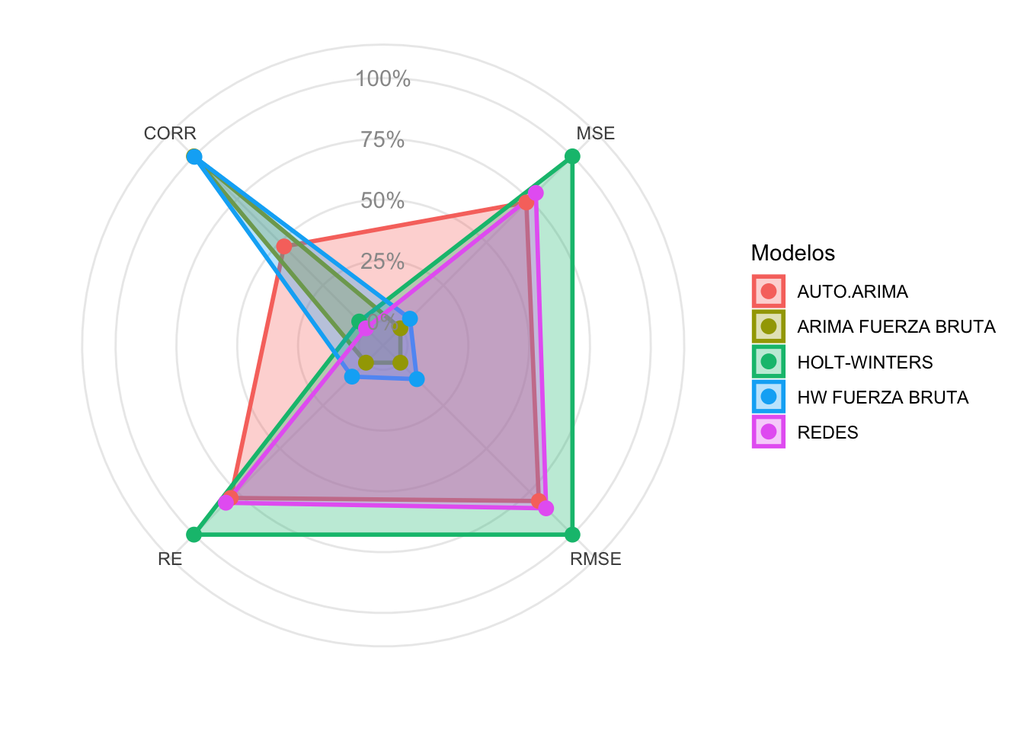

```r
grafico.errores(errores)
```

# f) Con el mejor modelo encontrado en el punto anterior genere la predicción de una semana, pero esta vez utilizando toda la serie de tiempo. Grafique la serie original y la predicción junto con el limite inferior y superior.

```r
modelo.arima.calibrado <- arima(serie, order = c(1, 2, 0), seasonal = list(order = c(1,
    1, 1), period = 7))

pred <- predict(modelo.arima.calibrado, n.ahead = 7)

p <- ts.union(prediccion = pred$pred, LimInf = pred$pred - pred$se, LimSup = pred$pred +
    pred$se)

fecha <- fecha.inicio + days(0:420)

predicciones <- ts.union(serie, p)

predicciones <- xts(xts(predicciones, order.by = fecha))

dygraph(predicciones, width = "100%") %>%
    dySeries("serie", label = "Actual") %>%
    dySeries(c("p.LimInf", "p.prediccion", "p.LimSup"), label = "Predicción") %>%
    dyRangeSelector(height = 20, strokeColor = "") %>%
    dyOptions(axisLineColor = "navy", gridLineColor = "lightblue")
```

[interactive chart not shown]

# 3. [25 puntos] El archivo `USA_CR.csv` contiene los movimientos de compra y venta del colón con respecto al dólar desde el 15 de Enero del 2016 al 20 de Septiembre del 2019. Utilizando la variable `TIPO_CAMBIO_VENTA` realice lo siguiente:

```r
datos <- read.table("../datos/USA_CR.csv", header = T, sep = ";", dec = ",")
# pasamos a formato fecha
datos$FECHA <- as.POSIXct(datos$FECHA, format = "%d %b %Y")

datos <- na.omit(datos)

str(datos)
```

```
'data.frame':   953 obs. of  3 variables:
 $ FECHA             : POSIXct, format: "2016-01-15" "2016-01-18" ...
 $ TIPO_CAMBIO_COMPRA: num  529 529 529 529 529 ...
 $ TIPO_CAMBIO_VENTA : num  541 541 541 542 542 ...
```

```r
fecha.inicio <- datos$FECHA[1]
fecha.final <- datos$FECHA[nrow(datos)]

total.fechas <- seq(from = fecha.inicio, to = fecha.final, by = "day")

faltan.fechas <- total.fechas[!total.fechas %in% datos$FECHA]


faltan.fechas
```

```
 [1] "2016-01-16 CST" "2016-01-17 CST" "2016-01-23 CST" "2016-01-24 CST"
 [5] "2016-01-30 CST" "2016-01-31 CST" "2016-02-06 CST" "2016-02-07 CST"
 [9] "2016-02-13 CST" "2016-02-14 CST" "2016-02-20 CST" "2016-02-21 CST"
[13] "2016-02-27 CST" "2016-02-28 CST" "2016-03-05 CST" "2016-03-06 CST"
[17] "2016-03-12 CST" "2016-03-13 CST" "2016-03-19 CST" "2016-03-20 CST"
[21] "2016-03-25 CST" "2016-03-26 CST" "2016-03-27 CST" "2016-04-02 CST"
[25] "2016-04-03 CST" "2016-04-09 CST" "2016-04-10 CST" "2016-04-16 CST"
[29] "2016-04-17 CST" "2016-04-23 CST" "2016-04-24 CST" "2016-04-30 CST"
[33] "2016-05-01 CST" "2016-05-07 CST" "2016-05-08 CST" "2016-05-14 CST"
[37] "2016-05-15 CST" "2016-05-21 CST" "2016-05-22 CST" "2016-05-28 CST"
[41] "2016-05-29 CST" "2016-06-04 CST" "2016-06-05 CST" "2016-06-11 CST"
[45] "2016-06-12 CST" "2016-06-18 CST" "2016-06-19 CST" "2016-06-25 CST"
[49] "2016-06-26 CST" "2016-07-02 CST" "2016-07-03 CST" "2016-07-09 CST"
[53] "2016-07-10 CST" "2016-07-16 CST" "2016-07-17 CST" "2016-07-23 CST"
[57] "2016-07-24 CST" "2016-07-30 CST" "2016-07-31 CST" "2016-08-06 CST"
[61] "2016-08-07 CST" "2016-08-13 CST" "2016-08-14 CST" "2016-08-20 CST"
[65] "2016-08-21 CST" "2016-08-27 CST" "2016-08-28 CST" "2016-09-03 CST"
[69] "2016-09-04 CST" "2016-09-10 CST" "2016-09-11 CST" "2016-09-17 CST"
[73] "2016-09-18 CST" "2016-09-24 CST" "2016-09-25 CST"
 [ reached 'max' / getOption("max.print") -- omitted 317 entries ]
```

## b) Convierta a serie de tiempo `ts` utilizando una frecuencia de forma que el Patrón-Estacional sea semanal.

```r
serie <- ts(datos$TIPO_CAMBIO_VENTA, frequency = 7, start = c(1, wday(fecha.inicio)))

serie
```

```
Time Series:
Start = c(1, 6)
End = c(137, 6)
Frequency = 7
 [1] 541.30 541.34 541.29 541.54 541.56 542.13 542.44 542.49 542.78 543.26
[11] 543.92 544.57 544.65 544.82 544.83 544.83 544.74 544.53 544.20 543.95
[21] 542.98 542.12 542.05 542.01 542.16 542.04 541.82 541.75 541.77 541.81
[31] 541.82 542.20 542.22 542.25 542.24 542.06 542.09 542.05 542.02 542.03
[41] 541.70 541.67 541.57 541.57 541.54 541.57 541.44 541.43 541.45 541.45
[51] 541.45 541.36 541.59 542.23 542.17 542.23 542.44 542.81 542.80 542.76
[61] 542.72 542.72 542.55 542.10 541.79 541.62 541.63 541.83 541.87 541.86
[71] 541.83 541.83 542.65 543.48 543.62
 [ reached getOption("max.print") -- omitted 878 entries ]
```

## c) Usando el último mes para pruebas y el resto de fechas para entrenamiento genere un modelo con `HOLT-WINTERS`, `HOLT-WINTERS Calibrado`, `Redes Neuronales`, `AUTO ARIMA` y `ARIMA CALIBRADO`, para este último utilice un periodo de 5.

```r
train <- head(serie, -20)
test <- tail(serie, 20)
```

### Holt-Winters

```r
modelo.HW <- hw(train, h = 20)
pred.HW <- forecast(modelo.HW, h = 20)
```

### Calibrado Holt-Winters

```r
calibrar.HW(train, test)
```

[output not shown]

[output cut: 413 more lines]

[output not shown]

```r
modelo.calibrado <- hw(train, alpha = 0.8, beta = 0.1, gamma = 0.1, h = 20)
pred.calibrado <- forecast(modelo.calibrado, h = 20)
```

### Redes Neuronales

```r
modelo.RN <- nnetar(train, size = 40)
pred.RN <- forecast(modelo.RN, h = 20)
```

### Auto-Arima

```r
auto.arima(train)
```

```
Series: train
ARIMA(2,1,2)

Coefficients:
         ar1      ar2      ma1     ma2
      1.4121  -0.5504  -0.9145  0.1168
s.e.  0.0818   0.0561   0.0897  0.0655

sigma^2 estimated as 0.9608:  log likelihood=-1301.83
AIC=2613.66   AICc=2613.73   BIC=2637.85
```

```r
modelo.arima <- arima(train, order = c(1, 1, 0), seasonal = list(order = c(0, 0,
    1), period = 7))
pred.arima <- predict(modelo.arima, n.ahead = 20)
```

### ARIMA Calibrado

```r
calibrar.arima(train, test, periodo = 5, 0:3, 0:1)
```

[output not shown]

```r
modelo.arima.calibrado <- arima(train, order = c(1, 0, 3), seasonal = list(order = c(1,
    0, 1), period = 5))

pred.arima.calibrado <- predict(modelo.arima.calibrado, n.ahead = 20)
```

# d) Con un gráfico mida el error de cada uno de los modelos anteriores y determine cuál de ellos es el mejor.

```r
errores <- tabla.errores(predicciones = list(pred.arima$pred, pred.arima.calibrado$pred,
    pred.HW$mean, pred.calibrado$mean, pred.RN$mean), real = test)

row.names(errores) <- c("AUTO.ARIMA", "ARIMA FUERZA BRUTA", "HOLT-WINTERS", "HW FUERZA BRUTA",
    "REDES")

errores
```

|  | MSE | RMSE | RE | CORR |
| --- | --- | --- | --- | --- |
| AUTO.ARIMA | 66.61262 | 8.161655 | 0.01217555 | 0.6193838 |
| ARIMA FUERZA BRUTA | 66.61921 | 8.162059 | 0.01219090 | 0.1304341 |
| HOLT-WINTERS | 171.81409 | 13.107787 | 0.02008762 | -0.8361031 |
| HW FUERZA BRUTA | 183.96705 | 13.563445 | 0.02104515 | -0.8287682 |
| REDES | 73.97104 | 8.600642 | 0.01291151 | 0.2869110 |

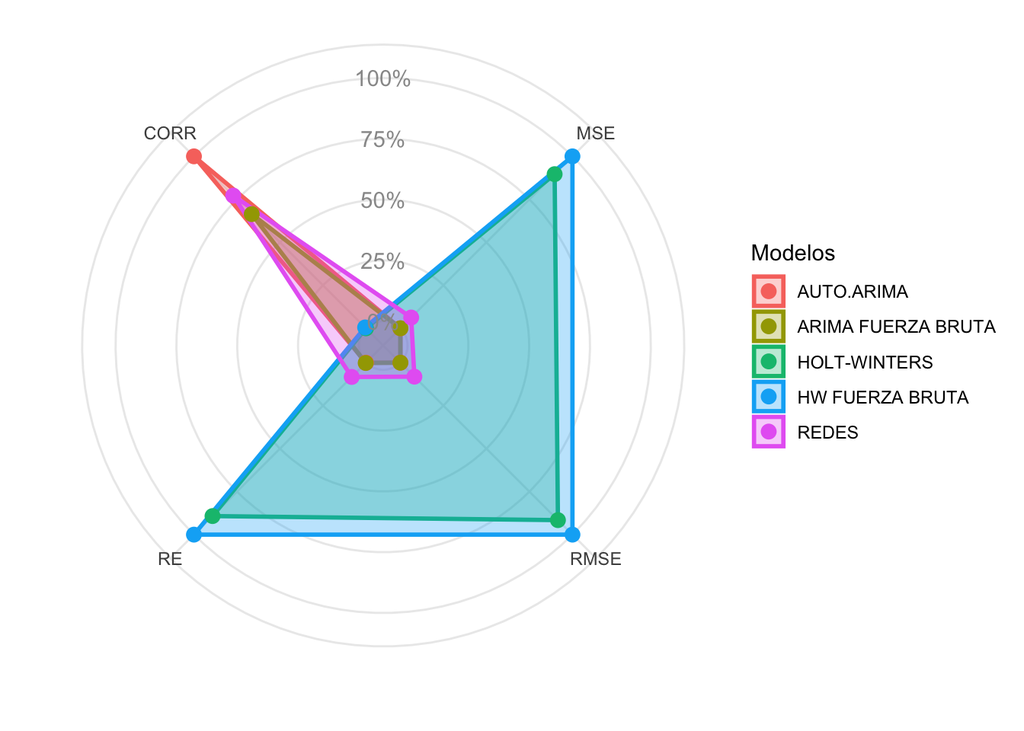

```r
grafico.errores(errores)
```

## e) Con el mejor modelo encontrado en el punto anterior genere la predicción de un mes, pero esta vez utilizando toda la serie de tiempo. Grafique la serie original y la predicción junto con el limite inferior y superior con `dygraph`.

```r
# con toda la serie
modelo <- nnetar(serie, size = 40)

pred <- forecast(modelo, h = 30, PI = TRUE)

p <- ts.union(prediccion = pred$mean, LimInf = pred$lower[, 2], LimSup = pred$upper[,
    2])

predicciones <- ts.union(serie, p)

fechas <- fecha.inicio + days(0:982)

predicciones <- xts(xts(predicciones, order.by = fechas))

dygraph(predicciones, width = "100%") %>%
    dySeries("serie", label = "Actual") %>%
    dySeries(c("p.LimInf", "p.prediccion", "p.LimSup"), label = "Predicción") %>%
    dyRangeSelector(height = 20, strokeColor = "") %>%
    dyOptions(axisLineColor = "navy", gridLineColor = "lightblue")
```

[interactive chart not shown]

# 4. **[10 puntos]** Desarrolle los ejercicios propuesto en las filminas 16, 17 y 18 de la presentación Funciones de Autocorrelación, Correlograma - ACF y Correlograma Parcial - PACF.

Los demás ejercicios del 5 al 9 están el pdf.

## 2.1

```r
Xt <- c(10, 3, -1, 3, 2, 5, 3, 2, -1, 3)

p1 <- round(cor(Xt[-1], Xt[-length(Xt)]), digits = 3)

p2 <- round(cor(Xt[-c(1:2)], Xt[-(rep(length(Xt), 2) - 0:1)]), digits = 3)

p3 <- round(cor(Xt[-c(1:3)], Xt[-(rep(length(Xt), 3) - 0:2)]), digits = 3)

p1
```

```
[1] 0.021
```

```r
p2
```

```
[1] -0.502
```

```r
p3
```

```
[1] -0.348
```

## 2.2

```r
p11 <- p1

p22 <- (p2 - p1^2)/(1 - p1^2)

p33 <- (p1^3 - p1 * p2 * (2 - p2) + p3 * (1 - p1^2))/(1 - p2^2 - 2 * p1^2 * (1 -
    p2))

p11
```

```
[1] 0.021
```

```r
p22
```

```
[1] -0.5026627
```

```r
p33
```

```
[1] -0.4305257
```

## 2.3

```r
p4 <- cor(Xt[-c(1:4)], Xt[-(rep(length(Xt), 4) - 0:3)])

P4 <- cbind(c(1, p1, p2, p3), c(p1, 1, p1, p2), c(p2, p1, 1, p1), c(p3, p2, p1, 1))
P44 <- cbind(c(1, p1, p2, p3), c(p1, 1, p1, p2), c(p2, p1, 1, p1), c(p1, p2, p3,
    p4))
p44 <- det(P44)/det(P4)
p44
```

```
[1] -0.5094852
```

```r
p5 <- cor(Xt[-c(1:5)], Xt[-(rep(length(Xt), 5) - 0:4)])
P5 <- cbind(c(1, p1, p2, p3, p4), c(p1, 1, p1, p2, p3), c(p2, p1, 1, p1, p2), c(p3,
    p2, p1, 1, p1), c(p4, p3, p2, p1, 1))
P55 <- cbind(c(1, p1, p2, p3, p4), c(p1, 1, p1, p2, p3), c(p2, p1, 1, p1, p2), c(p3,
    p2, p1, 1, p1), c(p1, p2, p3, p4, p5))
p55 <- det(P55)/det(P5)
p55
```

```
[1] 0.06504685
```

## 2.3

```r
PACF <- function(serie, k) {

    p <- c()

    m.pk <- diag(x = k)

    for (ind in 1:(k - 1)) {
        p[ind] <- round(cor(Xt[-c(1:ind)], Xt[-(rep(length(serie), ind) - 0:(ind -
            1))]), digits = 3)
    }

    for (i in 1:dim(m.pk)[1]) {
        for (j in 1:dim(m.pk)[2]) {
            if (j > i) {
                m.pk[i, j] <- p[j - i]
            }
        }
    }

    m.pk <- t(m.pk)

    for (i in 1:dim(m.pk)[1]) {
        for (j in 1:dim(m.pk)[2]) {
            if (j > i) {
                m.pk[i, j] <- p[j - i]
            }
        }
    }

    pk <- round(cor(Xt[-c(1:k)], Xt[-(rep(length(serie), k) - 0:(k - 1))]), digits = 3)
    m.pkk <- cbind(m.pk[, -k], c(p, pk))

    return(det(m.pkk)/det(m.pk))
}

PACF(serie = Xt, k = 2)
```

```
[1] -0.5026627
```